# Reproducible Science

A Research Memorandum: Driver’s License Status and Communication Apprehension

Author

JIANGRAN GU

Published

July 30, 2026

## Researcher

**Researcher:** JIANGRAN GU **Date:** July 30, 2026 **JIANGRAN GU:** Does group communication apprehension predict whether, or how often, respondents use public transportation? **This memo’s sub-question:** Does holding a driver’s license (Q20) predict communication apprehension (CA)?

## Research Or Analytical Question

Does whether a respondent **holds a driver’s license** (Q20: “Do you have a license to drive a car?”, Yes/No) predict their level of **communication apprehension (CA)**, measured as the sum of 12 Likert-scale items (Q1–Q6: group-discussion apprehension; Q13–Q18: dyadic/interpersonal apprehension) from the PRCA-style instrument in `PRCAQualtricsExport_FileC.csv`?

## Data & Method

```python
import pandas as pd
import numpy as np
from scipy import stats
import matplotlib.pyplot as plt

df = pd.read_csv("PRCAQualtricsExport_FileC.csv")

# 12 Communication Apprehension items:
# Q1-Q6  = group discussion apprehension
# Q13-Q18 = dyadic / interpersonal conversation apprehension
ca_items = ["Q1", "Q2", "Q3", "Q4", "Q5", "Q6",
            "Q13", "Q14", "Q15", "Q16", "Q17", "Q18"]

# 5-point ordinal Likert recode (Strongly disagree = 1 ... Strongly agree = 5)
likert_map = {
    "Strongly disagree": 1,
    "Somewhat disagree": 2,
    "Neither agree nor disagree": 3,
    "Somewhat agree": 4,
    "Strongly agree": 5,
}

for c in ca_items:
    df[c + "_n"] = df[c].map(likert_map)

# Composite CA score = ordinal sum of all 12 items (per team's agreed coding
# scheme -- items are summed as-is with no reverse-scoring)
df["CA_total"] = df[[c + "_n" for c in ca_items]].sum(axis=1, skipna=False)

# Analytic sample: complete CA items + non-missing license status (Q20)
sub = df.dropna(subset=["CA_total", "Q20"]).copy()
sub["Q20"] = pd.Categorical(sub["Q20"], categories=["No", "Yes"])

print(f"Analytic N = {len(sub)}")
print(sub["Q20"].value_counts())
```

```
Analytic N = 163
Q20
Yes    138
No      25
Name: count, dtype: int64
```

CA items were recoded from text labels to a 1–5 ordinal scale (Strongly disagree = 1 → Strongly agree = 5) and summed across all 12 items to create a composite `CA_total` score (possible range 12–60). Respondents missing any of the 12 CA items or missing Q20 were listwise-deleted, leaving an analytic sample of N = 163 (138 “Yes” license holders, 25 “No”).

Group means were compared with an **independent-samples t-test**, with Levene’s test used to check the equal-variance assumption.

## Answer, Response, + Summary of Results

```python
desc = sub.groupby("Q20", observed=True)["CA_total"].agg(
    n="count", mean="mean", sd="std", median="median"
).round(2)
desc
```

| Q20 | n | mean | sd | median |
| --- | --- | --- | --- | --- |
| No | 25 | 37.40 | 2.53 | 37.0 |
| Yes | 138 | 36.38 | 2.55 | 36.0 |

```python
yes = sub.loc[sub["Q20"] == "Yes", "CA_total"]
no = sub.loc[sub["Q20"] == "No", "CA_total"]

lev_stat, lev_p = stats.levene(yes, no)
print(f"Levene's test: F = {lev_stat:.3f}, p = {lev_p:.3f}")

# Levene's test is non-significant -> equal variances assumed -> Student's t
t_stat, p_val = stats.ttest_ind(yes, no, equal_var=True)
df_t = len(yes) + len(no) - 2

pooled_sd = np.sqrt(
    ((len(yes) - 1) * yes.var() + (len(no) - 1) * no.var()) / df_t
)
cohens_d = (yes.mean() - no.mean()) / pooled_sd

print(f"t({df_t}) = {t_stat:.3f}, p = {p_val:.3f}")
print(f"Cohen's d = {cohens_d:.3f}")
```

```
Levene's test: F = 0.023, p = 0.881
t(161) = -1.833, p = 0.069
Cohen's d = -0.398
```

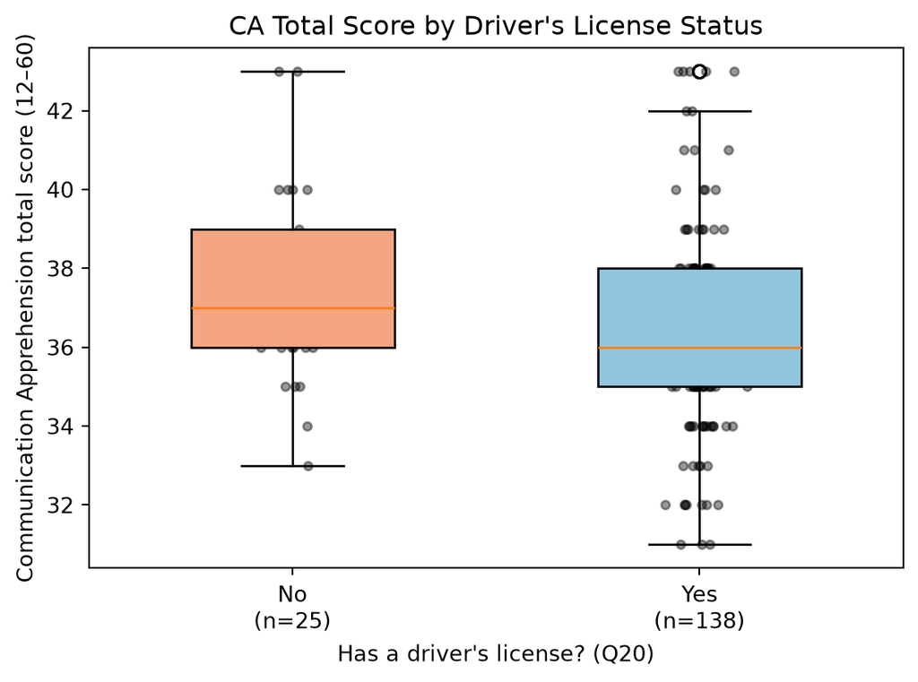

Figure 1: Communication Apprehension (CA) total score by driver’s license status

```python
fig, ax = plt.subplots(figsize=(6, 4.5))

groups = ["No", "Yes"]
data_by_group = [sub.loc[sub["Q20"] == g, "CA_total"] for g in groups]

bp = ax.boxplot(data_by_group, tick_labels=[f"{g}\n(n={len(d)})" for g, d in zip(groups, data_by_group)],
                 patch_artist=True, widths=0.5)
for patch, color in zip(bp["boxes"], ["#f4a582", "#92c5de"]):
    patch.set_facecolor(color)

# jittered raw points
rng = np.random.default_rng(42)
for i, d in enumerate(data_by_group, start=1):
    x = rng.normal(i, 0.04, size=len(d))
    ax.scatter(x, d, alpha=0.4, color="black", s=15)

ax.set_xlabel("Has a driver's license? (Q20)")
ax.set_ylabel("Communication Apprehension total score (12–60)")
ax.set_title("CA Total Score by Driver's License Status")
plt.tight_layout()
plt.show()
```

Using `PRCAQualtricsExport_FileC.csv`, respondents **without** a driver’s license reported a slightly **higher** mean CA score (M = 37.40, SD = 2.53, n = 25) than respondents **with** a license (M = 36.38, SD = 2.55, n = 138). Levene’s test indicated the equal-variance assumption was reasonable (F = 0.02, p = .881), so a Student’s independent-samples t-test was used. The difference was **not statistically significant at the conventional α = .05 level**, t(161) = -1.83, p = .069, although it approached significance at the α = .10 level. The effect size was small-to-moderate (Cohen’s d = -0.40), with the no-license group trending toward higher apprehension.

**Conclusion:** From these data, holding a driver’s license does **not** significantly predict communication apprehension at the .05 threshold, though there is a marginal (p < .10), small-to-moderate trend suggesting non-license-holders may report somewhat higher CA. This should be treated as suggestive rather than conclusive evidence.

## What questions or uncertainties remain?

- The composite `CA_total` was created by **summing raw ordinal codes without reverse-scoring** the positively-worded items (e.g., Q2, Q4, Q6, Q14, Q16, Q17), per the team’s agreed coding approach. A standard PRCA-style reverse-scored composite might change the magnitude (and possibly the direction) of the group difference — this is worth checking as a robustness test.
- The “No license” subgroup is small (n = 25), which limits statistical power; the marginal p-value (.069) could reflect low power as much as a true null effect.
- Does license status relate differently to the **group-discussion** (Q1–Q6) vs. **dyadic/interpersonal** (Q13–Q18) CA subscales separately, rather than only the combined total?
- How does license status intersect with the team’s core question — does CA (or license status) predict actual public-transportation use (Q26–Q27) or ride-share use (Q28–Q29)? A follow-up regression/mediation analysis could connect this sub-question back to the group’s shared research question.
- Possible confounds (age, car access [Q21], urban vs. rural location) were not controlled for here and could be examined in a multivariate model.

*Data source: `PRCAQualtricsExport_FileC.csv`, PRCA-style survey administered as part of Psych 755, University of Wisconsin–Madison. Variable definitions per `data_dictionary.csv`.*